# Dan Warren

[figure not shown]

[Google Scholar](http://scholar.google.com/citations?user=NTzu9c8AAAAJ&hl=en)  
[Orcid](http://orcid.org/0000-0002-8747-2451)  
[ResearcherID](http://www.researcherid.com/rid/B-3821-2010)  
[Scopus](http://www.scopus.com/authid/detail.url?authorId=7202133982)  
[GitHub (RWTY)](https://github.com/danlwarren/RWTY)  
[GitHub (ENMTools)](https://github.com/danlwarren/ENMTools)  
[Twitter](https://twitter.com/danlwarren)  
[Blog](http://speciesinspace.com)  
[Soundcloud](http://soundcloud.com/danwarren/tracks)  
Art by Ainsley Seago.

# About Me

I have broad interests across evolution, ecology, biogeography, and conservation biology. My primary research program focuses on using informatics approaches to answer large-scale questions in population biology, with a particular focus on species distribution models/environmental niche models. I also have active research programs in phylogenetic methods and theory, and neuroecology of marine fishes. I tend to do a lot of quantitative and computational methods development, and have developed several widely-used software packages for population biologists.

# Publications (last updated 2018-10-01)

For the most up-to-date information on what I’ve been doing, check [Google Scholar](http://scholar.google.com/citations?user=NTzu9c8AAAAJ&hl=en). You can also check me out on [Orcid](http://orcid.org/0000-0002-8747-2451), [ResearcherID](http://www.researcherid.com/rid/B-3821-2010), or [Scopus](http://www.scopus.com/authid/detail.url?authorId=7202133982), but those are updated considerably less often.  
The following is scraped automatically from Google Scholar, CrossRef, and Altmetric. It may contain errors depending on API changes, formatting issues, or the direction of the wind. For an up-to-date and correct CV, email me.

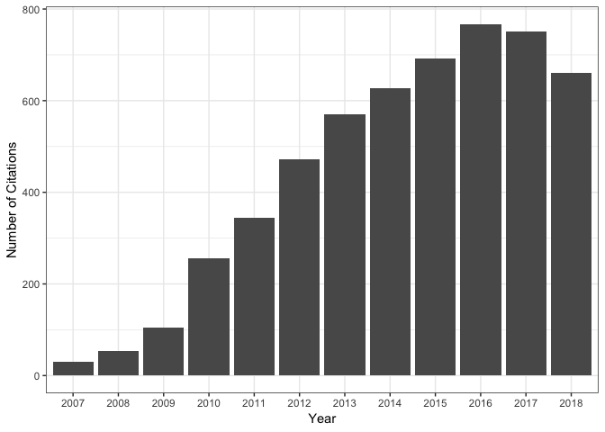

Total citations: **5396**  
h index: **18**  
i-10 index: **24**

- TL Iglesias, A Dornburg, DL Warren, PC Wainwright, L Schmitz, …. (2018). Eyes Wide Shut: the impact of dim‐light vision on neural investment in marine teleosts. Journal of evolutionary biology 31 (8), 1082-1092.  
  Citations: **0**
- DL Warren, L Beaumont, R Dinnage, J Baumgartner. (2018). New methods for measuring ENM breadth and overlap in environmental space. Ecography .  
  Citations: **0**
- A Dornburg, DL Warren, KL Zapfe, R Morris, TL Iglesias, A Lamb, …. (2018). Testing ontogenetic patterns of sexual size dimorphism against expectations of the expensive tissue hypothesis, an intraspecific example using oyster toadfish (Opsanus tau). Ecology and evolution 8 (7), 3609-3616.  
  Citations: **0**
- DL Warren, AJ Geneva, R Lanfear. (2017). RWTY (R We There Yet): An R package for examining convergence of Bayesian phylogenetic analyses. Molecular biology and evolution 34 (4), 1016-1020.  
  Citations: **32**
- F d’Errico, WE Banks, DL Warren, G Sgubin, K van Niekerk, …. (2017). Identifying early modern human ecological niche expansions and associated cultural dynamics in the South African Middle Stone Age. Proceedings of the National Academy of Sciences 114 (30), 7869-7876.  
  Citations: **13**
- A Dornburg, EJ Forrestel, JA Moore, TL Iglesias, A Jones, L Rao, …. (2017). An assessment of sampling biases across studies of diel activity patterns in marine ray-finned fishes (Actinopterygii). Bulletin of Marine Science 93 (2), 611-639.  
  Citations: **3**
- AD Lamb, GJ Watkins-Colwell, JA Moore, DL Warren, TL Iglesias, …. (2017). Endolymphatic Sac Use and Reproductive Activity in the Lesser Antilles Endemic Gecko Gonatodes antillensis (Gekkota: Sphaerodactylidae). Bulletin of the Peabody Museum of Natural History 58 (1), 17-29.  
  Citations: **2**
- A Tingstad, RJ Lempert, M Moskwik, DL Warren, C Parmesan, LO Mearns, …. (2017). Demonstrating the Applicability of a Robust Decision Making (RDM) to Conservation Decision-Making Under Uncertain Future Climate. Journal of Conservation Planning 13, 11-24.  
  Citations: **1**
- LJ Beaumont, E Graham, DE Duursma, PD Wilson, A Cabrelli, …. (2016). Which species distribution models are more (or less) likely to project broad-scale, climate-induced shifts in species ranges?. Ecological Modelling 342, 135-146.  
  Citations: **13**
- R Lanfear, X Hua, DL Warren. (2016). Estimating the effective sample size of tree topologies from Bayesian phylogenetic analyses. Genome biology and evolution 8 (8), 2319-2332.  
  Citations: **13**
- M Cardillo, DL Warren. (2016). Analysing patterns of spatial and niche overlap among species at multiple resolutions. Global Ecology and Biogeography 25 (8), 951-963.  
  Citations: **8**
- A Dornburg, C Lippi, S Federman, JA Moore, DL Warren, TL Iglesias, …. (2016). Disentangling the Influence of Urbanization and Invasion on Endemic Geckos in Tropical Biodiversity Hot Spots: A Case Study of Phyllodactylus martini (Squamata …. Bulletin of the Peabody Museum of Natural History 57 (2), 147-164.  
  Citations: **1**
- KP Mainali, DL Warren, K Dhileepan, A McConnachie, L Strathie, …. (2015). Projecting future expansion of invasive species: comparing and improving methodologies for species distribution modeling. Global change biology 21 (12), 4464-4480.  
  Citations: **53**
- X Hua, P Cowman, D Warren, L Bromham. (2015). Longevity is linked to mitochondrial mutation rates in rockfish: a test using poisson regression. Molecular biology and evolution 32 (10), 2633-2645.  
  Citations: **10**
- TL Iglesias, A Dornburg, MC Brandley, ME Alfaro, DL Warren. (2015). Life in the unthinking depths: energetic constraints on encephalization in marine fishes. Journal of evolutionary biology 28 (5), 1080-1090.  
  Citations: **5**
- DL Warren, M Cardillo, DF Rosauer, DI Bolnick. (2014). Mistaking geography for biology: inferring processes from species distributions. Trends in Ecology & Evolution 29 (10), 572-580.  
  Citations: **116**
- DL Warren, AN Wright, SN Seifert, HB Shaffer. (2014). Incorporating model complexity and spatial sampling bias into ecological niche models of climate change risks faced by 90 C alifornia vertebrate species of concern. Diversity and distributions 20 (3), 334-343.  
  Citations: **75**
- DL Warren. (2013). ‘Niche modeling’: that uncomfortable sensation means it’s working. A reply to McInerny and Etienne. Trends in ecology & evolution 28 (4), 193-194.  
  Citations: **15**
- DL Warren. (2012). In defense of ‘niche modeling’. Trends in ecology & evolution 27 (9), 497-500.  
  Citations: **110**
- MC Brandley, RL Young, DL Warren, MB Thompson, GP Wagner. (2012). Uterine Gene Expression in the Live-Bearing Lizard, Chalcides ocellatus, Reveals Convergence of Squamate Reptile and Mammalian Pregnancy Mechanisms. Genome biology and evolution 4 (3), 394-411.  
  Citations: **48**
- DL Warren, TL Iglesias. (2012). No evidence for the ‘expensive‐tissue hypothesis’ from an intraspecific study in a highly variable species. Journal of evolutionary biology 25 (6), 1226-1231.  
  Citations: **20**
- A Dornburg, JA Moore, R Webster, DL Warren, MC Brandley, TL Iglesias, …. (2012). Molecular phylogenetics of squirrelfishes and soldierfishes (Teleostei: Beryciformes: Holocentridae): Reconciling more than 100 years of taxonomic confusion. Molecular phylogenetics and Evolution 65 (2), 727-738.  
  Citations: **18**
- DL Warren, NL Bennett. (2012). Niches. Oxford Bibliographies Online: Ecology .  
  Citations: **0**
- DL Warren, SN Seifert. (2011). Ecological niche modeling in Maxent: the importance of model complexity and the performance of model selection criteria. Ecological applications 21 (2), 335-342.  
  Citations: **718**
- RE Glor, D Warren. (2011). Testing ecological explanations for biogeographic boundaries. Evolution 65 (3), 673-683.  
  Citations: **95**
- UG Mueller, AS Mikheyev, E Hong, R Sen, DL Warren, SE Solomon, …. (2011). Evolution of cold-tolerant fungal symbionts permits winter fungiculture by leafcutter ants at the northern frontier of a tropical ant–fungus symbiosis. Proceedings of the National Academy of Sciences 108 (10), 4053-4056.  
  Citations: **59**
- A Dornburg, DL Warren, T Iglesias, MC Brandley. (2011). Natural history observations of the ichthyological and herpetological fauna on the island of Curaçao (Netherlands). Bulletin of the Peabody Museum of Natural History 52 (1), 181-186.  
  Citations: **5**
- D Warren. (2011). Son of Strelka, Son of God. International House of Dancakes Blog and Podcast 6.  
  Citations: **2**
- DL Warren, RE Glor, M Turelli. (2010). ENMTools: a toolbox for comparative studies of environmental niche models. Ecography 33 (3), 607-611.  
  Citations: **832**
- T Nakazato, DL Warren, LC Moyle. (2010). Ecological and geographic modes of species divergence in wild tomatoes. American Journal of Botany 97 (4), 680-693.  
  Citations: **161**
- L Mandle, DL Warren, MH Hoffmann, AT Peterson, J Schmitt, …. (2010). Conclusions about niche expansion in introduced Impatiens walleriana populations depend on method of analysis. PLoS One 5 (12), e15297.  
  Citations: **54**
- MC Brandley, DL Warren, AD Leaché, JA McGuire. (2009). Homoplasy and clade support. Systematic biology 58 (2), 184-198.  
  Citations: **23**
- JAA Nylander, JC Wilgenbusch, DL Warren, DL Swofford. (2008). AWTY (are we there yet?): a system for graphical exploration of MCMC convergence in Bayesian phylogenetics. Bioinformatics 24 (4), 581-583.  
  Citations: **1728**
- DL Warren, RE Glor, M Turelli. (2008). Environmental niche equivalency versus conservatism: quantitative approaches to niche evolution. Evolution 62 (11), 2868-2883.  
  Citations: **1101**
- MC Brandley, AD Leaché, DL Warren, JA McGuire. (2006). Are unequal clade priors problematic for Bayesian phylogenetics?. Systematic biology 55 (1), 138-146.  
  Citations: **35**
- DL Warren, J Wilgenbusch, DL Swofford. (2003). Converge: A program for implementing MCMC convergence diagnostics. Available from the authors at danwarren@ ucdavis. edu .  
  Citations: **7**
- DL Warren, JH Morrissey, PF Neuenschwander. (1999). Proteolysis of Blood Coagulation Factor VIII by the Factor VIIa− Tissue Factor Complex: Generation of an Inactive Factor VIII Cofactor. Biochemistry 38 (20), 6529-6536.  
  Citations: **10**